# ST 558 Homework 6

John Hinic

2022-06-10

# Summarizing Data

## Reading in Data

Reading in the raw data file:

```r
crabs <- read_fwf(
  "crabs.txt",
  fwf_widths(c(3, 3, 6, 3, 5, NA),
             c("color", "spine", "width", "satell", "weight", "y")),
  skip = 1
)
```

Re-formatting and re-levelling the factor variables in the dataset:

```r
crabs <- crabs %>%
  mutate(
    color = factor(color, labels = c("light", "medium", "dark", "darker")),
    spine = factor(spine, labels = c("Both Good", "One Worn/Broken", "Both Worn/Broken")),
    y = factor(y, labels = c("No Satellite", "At least 1 Satellite"))
  )
crabs
```

```
## # A tibble: 173 x 6
##    color  spine            width satell weight y
##    <fct>  <fct>            <dbl>  <dbl>  <dbl> <fct>
##  1 medium Both Worn/Broken  28.3      8   3050 At least 1 Satellite
##  2 dark   Both Worn/Broken  22.5      0   1550 No Satellite
##  3 light  Both Good         26        9   2300 At least 1 Satellite
##  4 dark   Both Worn/Broken  24.8      0   2100 No Satellite
##  5 dark   Both Worn/Broken  26        4   2600 At least 1 Satellite
##  6 medium Both Worn/Broken  23.8      0   2100 No Satellite
##  7 light  Both Good         26.5      0   2350 No Satellite
##  8 dark   One Worn/Broken   24.7      0   1900 No Satellite
##  9 medium Both Good         23.7      0   1950 No Satellite
## 10 dark   Both Worn/Broken  25.6      0   2150 No Satellite
## # ... with 163 more rows
```

## Creating Contingency Tables

One-way contingency tables of spine:

```r
# using table()
table(crabs$spine)
```

```
##
##        Both Good  One Worn/Broken Both Worn/Broken
##               37               15              121
```

```r
# using tidyverse
crabs %>%
  count(spine)
```

```
## # A tibble: 3 x 2
##   spine                n
##   <fct>            <int>
## 1 Both Good           37
## 2 One Worn/Broken     15
## 3 Both Worn/Broken   121
```

Two-way contingency tables of spine x satellite:

```r
# using table()
table(crabs$satell, crabs$spine)
```

```
##
##      Both Good One Worn/Broken Both Worn/Broken
##   0         11               8               43
##   1          3               0               13
##   2          1               0                8
##   3          2               2               15
##   4          4               3               12
##   5          7               0                8
##   6          3               2                8
##   7          1               0                3
##   8          2               0                4
##   9          2               0                1
##   10         0               0                3
##   11         0               0                1
##   12         0               0                1
##   14         1               0                0
##   15         0               0                1
```

```r
# using tidyverse and pivoting to wide format
crabs %>%
  count(spine, satell) %>%
  pivot_wider(names_from = satell, values_from = n, values_fill = 0)
```

```
## # A tibble: 3 x 16
##   spine    `0`   `1`   `2`   `3`   `4`   `5`   `6`   `7`   `8`   `9`  `14`  `10`
##   <fct>  <int> <int> <int> <int> <int> <int> <int> <int> <int> <int> <int> <int>
## 1 Both ~    11     3     1     2     4     7     3     1     2     2     1     0
## 2 One W~     8     0     0     2     3     0     2     0     0     0     0     0
## 3 Both ~    43    13     8    15    12     8     8     3     4     1     0     3
## # ... with 3 more variables: `11` <int>, `12` <int>, `15` <int>
```

From the first table, we can see from the top left cell that there were 11 crabs with 0 satellites that had both spines(?) in good condition. We can also see that the highest frequency category was crabs with 0 satellites and both worn/broken, with 43 total observations.

*I wasn’t sure how wide we were supposed to pivot the second table, so I used the number of satellites as columns since that is the wider version - although I think that looks pretty bad, so I would definitely use the spine variable to name the columns in reality.

```r
# using table() for 3-way table
threeWayTable <- table(crabs$satell, crabs$spine, crabs$color)
threeWayTable
```

```
## , ,  = light
##
##
##      Both Good One Worn/Broken Both Worn/Broken
##   0          2               0                1
##   1          0               0                0
##   2          1               0                0
##   3          0               1                0
##   4          1               0                0
##   5          1               0                0
##   6          2               1                0
##   7          0               0                0
##   8          1               0                0
##   9          1               0                0
##   10         0               0                0
```

[output cut: 64 more lines]

```r
# subsetting to only crabs with darker color
threeWayTable[ , , 4]
```

```
##
##      Both Good One Worn/Broken Both Worn/Broken
##   0          1               1               13
##   1          0               0                0
##   2          0               0                0
##   3          0               0                2
##   4          0               0                1
##   5          0               0                1
##   6          0               0                0
##   7          0               0                0
##   8          0               0                1
##   9          0               0                0
##   10         0               0                1
##   11         0               0                0
##   12         0               0                1
##   14         0               0                0
##   15         0               0                0
```

Consistent with the entire sample of crabs, we can see that the most common category among darker crabs is still 0 satellites and both worn/broken with 13 observations.

## Plotting the Data

Side-by-side bar plots of color and spine:

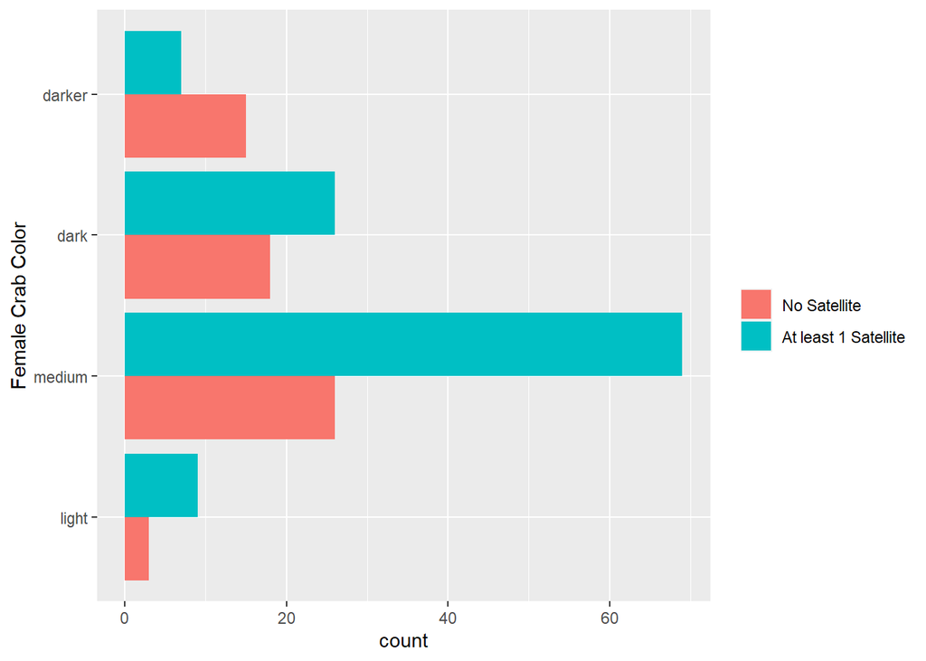

```r
# crab color by satellites
crabs %>%
  ggplot(aes(color, fill = y)) +
  geom_bar(position = "dodge") +
  coord_flip() +
  labs(x = "Female Crab Color") +
  scale_fill_discrete(name = "")
```

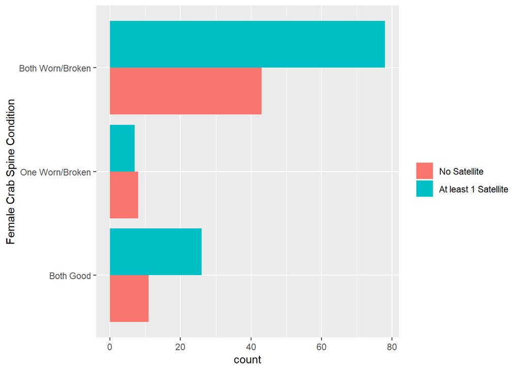

```r
# crab spine condition by satellites
crabs %>%
  ggplot(aes(spine, fill = y)) +
  geom_bar(position = "dodge") +
  coord_flip() +
  labs(x = "Female Crab Spine Condition") +
  scale_fill_discrete(name = "")
```

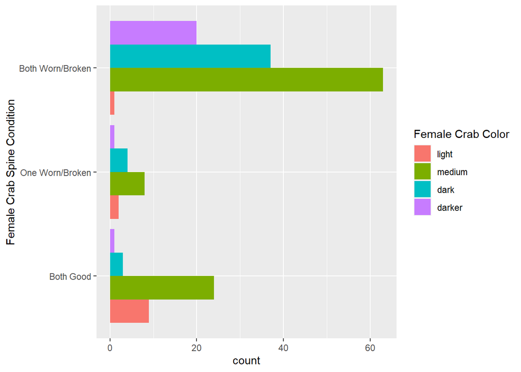

```r
# crab spine condition by color
crabs %>%
  ggplot(aes(spine, fill = color)) +
  geom_bar(position = "dodge") +
  coord_flip() +
  labs(x = "Female Crab Spine Condition") +
  scale_fill_discrete(name = "Female Crab Color")
```

A couple things that stood out to me from these bar plots is that it seems like female crabs with “darker” color are not doing particularly well; they are the only color that has more females with no satellites than females with at least one satellite. It also appears that darker females have a much higher proportion with both spines worn/broken than otherwise.

Faceted side-by-side bar plots:

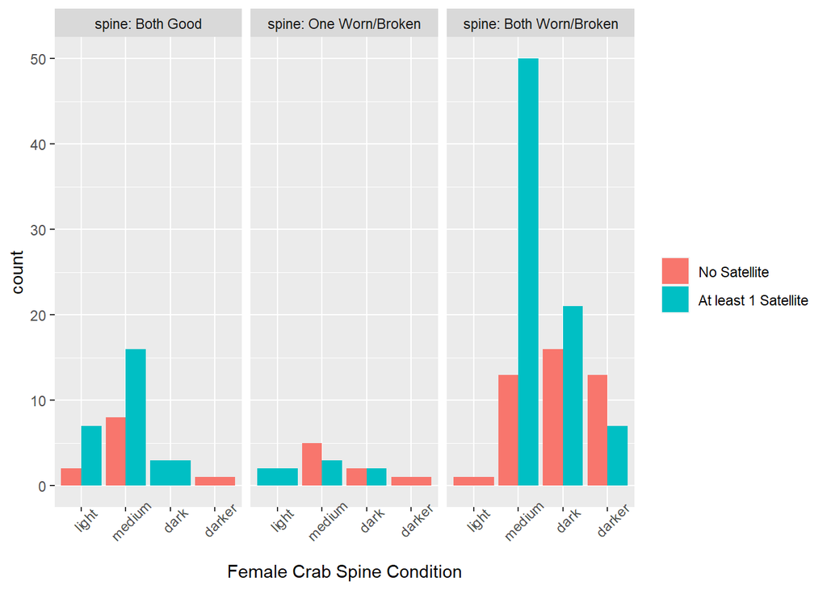

```r
crabs %>%
  ggplot(aes(color, fill = y)) +
  geom_bar(position = "dodge") +
  labs(x = "Female Crab Spine Condition") +
  scale_fill_discrete(name = "") +
  theme(axis.text.x = element_text(angle = 45)) +
  facet_wrap(. ~ spine, labeller = label_both)
```

The main thing I notice here is from the far right plot; there is *clearly* a downward trend in the proportion of female crabs with at least one satellite as the color gets darker.I think the sample sizes of crabs with more healthy spines is not large enough to draw much from.

Summary of weight:

```r
crabs %>%
  group_by(color, y) %>%
  summarise(Avg = mean(weight), SD = sd(weight), Median = median(weight), IQR = IQR(weight), n = n())
```

```
## # A tibble: 8 x 7
##   color  y                      Avg    SD Median   IQR     n
##   <fct>  <fct>                <dbl> <dbl>  <dbl> <dbl> <int>
## 1 light  No Satellite         2525   152.   2600  138.     3
## 2 light  At least 1 Satellite 2664.  442.   2700  650      9
## 3 medium No Satellite         2242.  482.   2200  512.    26
## 4 medium At least 1 Satellite 2649.  615.   2700  800     69
## 5 dark   No Satellite         1907.  348.   1900  462.    18
## 6 dark   At least 1 Satellite 2571.  495.   2575  719.    26
## 7 darker No Satellite         2162.  436.   2150  650     15
## 8 darker At least 1 Satellite 2200   523.   2100  200      7
```

From this table, we can see that darker female crabs with 1+ satellite have a mean weight of 2200g, a standard deviation of 523g, a median of 2100g, and an IQR of 200. However this group only includes 7 crabs so it is not particularly reliable.

Box plots of weight and width:

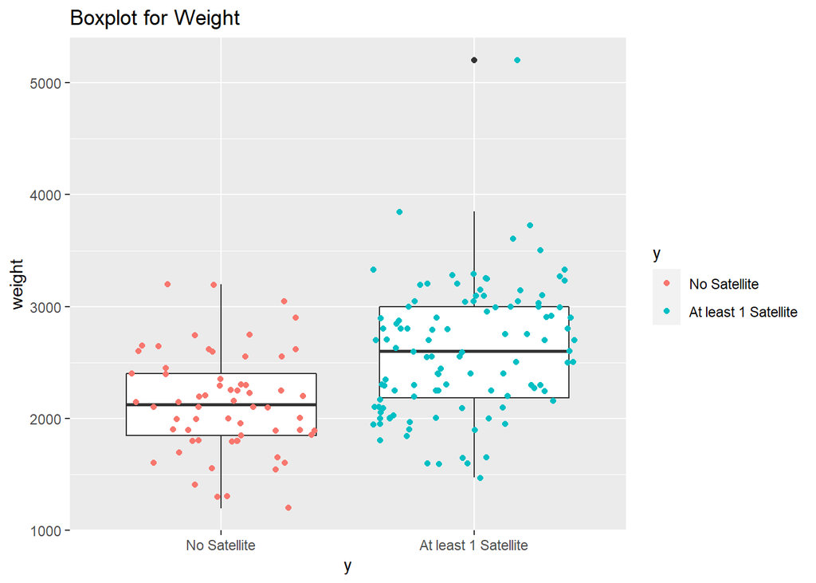

```r
# weight by y
crabs %>%
  ggplot(aes(y, weight)) +
  geom_boxplot() +
  geom_jitter(aes(color = y)) +
  labs(title = "Boxplot for Weight")
```

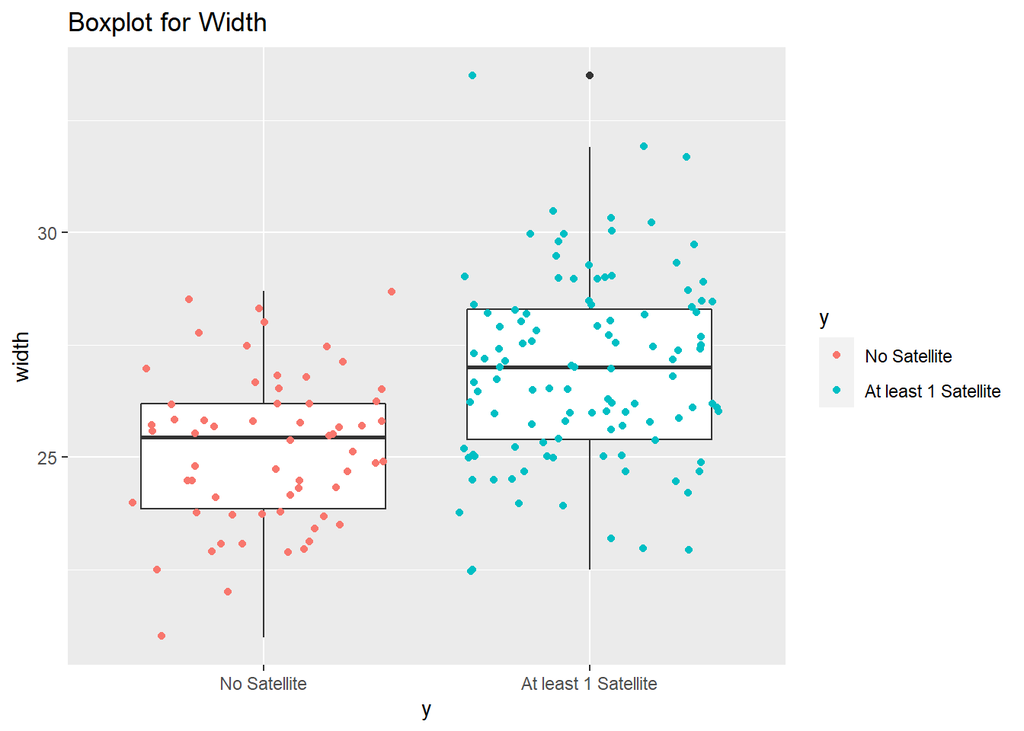

```r
# width by y
crabs %>%
  ggplot(aes(y, width)) +
  geom_boxplot() +
  geom_jitter(aes(color = y)) +
  labs(title = "Boxplot for Width")
```

One thing that is very clear from these boxplots is that the female crabs with at least one satellite tend to be overall larger than the ones with no satellite. On the weight plot, one of the crabs with 1+ satellite is also a clear outlier (although the median/Q1/Q3 are all robust so that wouldn’t impact these plots too much). We can see that there is also an outlier on the width plot that is likely the same crab, but that one is not quite as extreme as the weight.

Finding correlation of weight/width and plotting line of best fit:

```r
# finding correlation and outputting
corr <- cor(crabs$width, crabs$weight)
paste0("The linear correlation between weight and width is ", round(corr, 3), ".")
```

```
## [1] "The linear correlation between weight and width is 0.887."
```

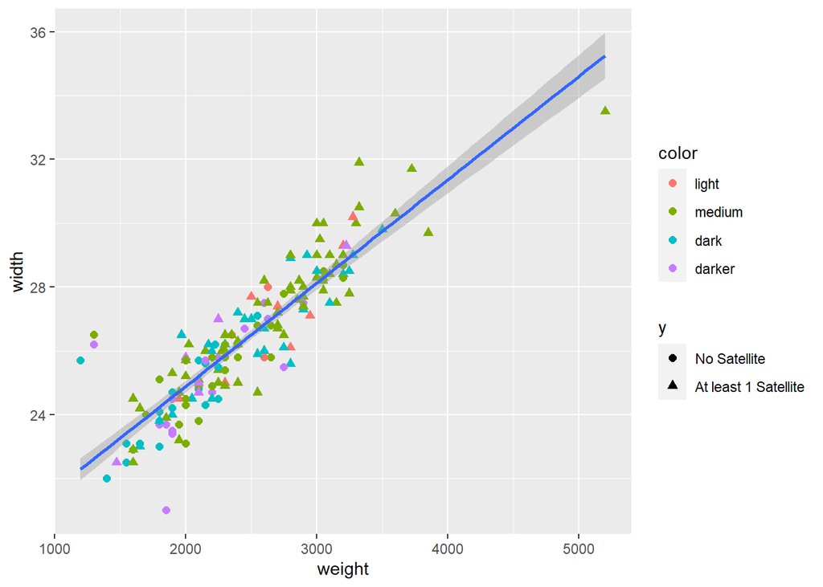

```r
# plotting width by weight and line of best fit
crabs %>%
  ggplot(aes(weight, width)) +
  geom_point(aes(color = color, shape = y), size = 2) +
  geom_smooth(method = lm)
```

We can see from the numeric correlation of 0.887 that there is a very strong, positive relationship between the weight and width of a female crab, which is not surprising. Upon inspection of the plot, we can see the crab that is *much* heavier than the rest on the far right. We can also see that the three lowest weight crabs are actually much wider than expected. I would be curious if those crabs had some kind of defect that lead to that, because they are very unusual observations.